# FinalProject

### Variable selection by correlation

To start with, we are considering following variables for model building.

“bedrooms”, “bathrooms”, “sqft_living”, “sqft_lot”, “newFloors”, “newView”, “newCondition”, “newGrade”, “sqft_above”, “sqft_basement”, “sqft_living15”, “sqft_lot15”, “yr_built”

```r
# Selected columns for first pass.

reducedHouseData = newHouseData[, c("price", "bedrooms", "bathrooms", "sqft_living", "sqft_lot", "newFloors", "newView", "newCondition", "newGrade", "sqft_above", "sqft_basement", "sqft_living15",    "sqft_lot15", "yr_built")]
```

#### Create a pairs plot to see which variables are highly correlated.

- This will visually indicate which variables might be redundant in the model.
- And which variables are suited for any kind of transformation.

```r
# pairs(reducedHouseData)
```

#### Print correlation matrix

```r
round(cor(subset(reducedHouseData, select = -c(newView, newCondition, newGrade))), 2)
```

```
##               price bedrooms bathrooms sqft_living sqft_lot newFloors
## price          1.00     0.31      0.53        0.70     0.09      0.26
## bedrooms       0.31     1.00      0.52        0.58     0.03      0.18
## bathrooms      0.53     0.52      1.00        0.75     0.09      0.50
## sqft_living    0.70     0.58      0.75        1.00     0.17      0.35
## sqft_lot       0.09     0.03      0.09        0.17     1.00     -0.01
## newFloors      0.26     0.18      0.50        0.35    -0.01      1.00
## sqft_above     0.61     0.48      0.69        0.88     0.18      0.52
## sqft_basement  0.32     0.30      0.28        0.44     0.02     -0.25
## sqft_living15  0.59     0.39      0.57        0.76     0.14      0.28
## sqft_lot15     0.08     0.03      0.09        0.18     0.72     -0.01
## yr_built       0.05     0.15      0.51        0.32     0.05      0.49
##               sqft_above sqft_basement sqft_living15 sqft_lot15 yr_built
## price               0.61          0.32          0.59       0.08     0.05
## bedrooms            0.48          0.30          0.39       0.03     0.15
## bathrooms           0.69          0.28          0.57       0.09     0.51
## sqft_living         0.88          0.44          0.76       0.18     0.32
## sqft_lot            0.18          0.02          0.14       0.72     0.05
## newFloors           0.52         -0.25          0.28      -0.01     0.49
## sqft_above          1.00         -0.05          0.73       0.19     0.42
## sqft_basement      -0.05          1.00          0.20       0.02    -0.13
## sqft_living15       0.73          0.20          1.00       0.18     0.33
## sqft_lot15          0.19          0.02          0.18       1.00     0.07
## yr_built            0.42         -0.13          0.33       0.07     1.00
```

- We can see that correlation is very high in following combinations.
  - sqft_living and bathrooms –> 0.75
  - sqft_living and sqft_above –> 0.88
  - sqft_living and sqft_living15 –> 0.76
  - sqft_lot and sqft_lot15 –> 0.72
  - sqft_living15 and sqft_above –> 0.73

#### Print Variance Inflation factor (VIF) to understand which variables explain variance of each other the most.

This will help us eliminate any redundant variables.

```r
round(faraway::vif(subset(reducedHouseData, select = -c(newView, newCondition, newGrade))), 2)
```

```
##         price      bedrooms     bathrooms   sqft_living      sqft_lot
##          2.32          1.64          3.30           Inf          2.09
##     newFloors    sqft_above sqft_basement sqft_living15    sqft_lot15
##          1.89           Inf           Inf          2.60          2.12
##      yr_built
##          1.79
```

```r
round(faraway::vif(subset(reducedHouseData, select = -c(newView, newCondition, newGrade, sqft_above))), 2)
```

```
##         price      bedrooms     bathrooms   sqft_living      sqft_lot
##          2.32          1.64          3.30          5.98          2.09
##     newFloors sqft_basement sqft_living15    sqft_lot15      yr_built
##          1.89          1.79          2.60          2.12          1.79
```

- VIF is still high and we know that there are following high correlation present in the data set.
  - sqft_living and bathrooms –> 0.75
  - sqft_living and sqft_living15 –> 0.76
  - sqft_lot and sqft_lot15 –> 0.72
- `Remove sqft_living15 and sqft_lot15` and check VIF again.

```r
round(faraway::vif(subset(reducedHouseData, select = -c(newView, newCondition, newGrade, sqft_above, sqft_living15, sqft_lot15))), 2)
```

```
##         price      bedrooms     bathrooms   sqft_living      sqft_lot
##          2.25          1.64          3.30          4.42          1.06
##     newFloors sqft_basement      yr_built
##          1.85          1.71          1.75
```

- This looks more reasonable.

### Try building first model.

- Splitting dataset into train and test set.

```r
set.seed(420)
train_size = floor(0.8 * nrow(newHouseData))
train_idx = sample(seq(1: nrow(newHouseData)), train_size)
train_house_data = newHouseData[train_idx, ]
test_house_data = newHouseData[-train_idx, ]
```

- Try backward AIC first.

```r
# With grade as continuous.
# 0.632719, 13, 226355.5
# model_start = lm(price ~ bedrooms + bathrooms + sqft_living + sqft_lot + sqft_basement + yr_built + newFloors + newView + newCondition + grade ,
#                 data = train_house_data)

# With new grade
# 0.5882713, 13, 239658.8
# model_start = lm(price ~ bedrooms + bathrooms + sqft_living + sqft_lot + sqft_basement + yr_built + newFloors + newView + newCondition + newGrade ,
#                 data = train_house_data)

# With grade as continuous numeric.
# 0.6473623 --> 13, 0.3140581 (RMSE is small because it is log.)
model_start = lm(log(price) ~ bedrooms + bathrooms + sqft_living + I(1/sqft_lot) + sqft_basement + yr_built + newFloors + newView + newCondition + grade,
                 data = train_house_data)

# With new grade. Performance suffers
# 0.6045867 --> 11, 0.3325646
# model_start = lm(log(price) ~ bedrooms + bathrooms + sqft_living + I(1/sqft_lot) + sqft_basement + yr_built + newFloors + newView + newCondition + newGrade,
#                 data = train_house_data)

n = nrow(train_house_data)
house_model_bak_aic_add_all = step(model_start, direction = "backward", k = 2, trace = 0)
summary(house_model_bak_aic_add_all)$adj.r.squared
```

```
## [1] 0.6473421
```

```r
length(coef(house_model_bak_aic_add_all))
```

```
## [1] 12
```

```r
calc_loocv_rmse(house_model_bak_aic_add_all)
```

```
## [1] 0.3140565
```

```r
summary(house_model_bak_aic_add_all)
```

```
##
## Call:
## lm(formula = log(price) ~ bedrooms + bathrooms + sqft_living +
##     I(1/sqft_lot) + sqft_basement + yr_built + newFloors + newView +
##     newCondition + grade, data = train_house_data)
##
## Residuals:
##      Min       1Q   Median       3Q      Max
## -2.00432 -0.21107  0.01325  0.20808  1.38392
##
## Coefficients:
##                 Estimate Std. Error t value Pr(>|t|)
## (Intercept)    2.175e+01  2.072e-01 104.933  < 2e-16 ***
## bedrooms      -1.797e-02  3.263e-03  -5.508 3.68e-08 ***
## bathrooms      7.523e-02  5.626e-03  13.372  < 2e-16 ***
## sqft_living    1.955e-04  6.300e-06  31.030  < 2e-16 ***
## I(1/sqft_lot)  2.759e+02  1.859e+01  14.842  < 2e-16 ***
## sqft_basement  1.400e-05  7.868e-06   1.779   0.0753 .
## yr_built      -5.674e-03  1.084e-04 -52.357  < 2e-16 ***
## newFloors      3.733e-02  7.383e-03   5.057 4.30e-07 ***
## newView1       1.362e-01  9.291e-03  14.657  < 2e-16 ***
## newCondition1  1.523e-01  2.490e-02   6.115 9.83e-10 ***
## newCondition2  1.923e-01  2.490e-02   7.723 1.20e-14 ***
## grade          2.216e-01  3.537e-03  62.637  < 2e-16 ***
## ---
## Signif. codes:  0 '***' 0.001 '**' 0.01 '*' 0.05 '.' 0.1 ' ' 1
##
## Residual standard error: 0.3139 on 17278 degrees of freedom
## Multiple R-squared:  0.6476, Adjusted R-squared:  0.6473
## F-statistic:  2886 on 11 and 17278 DF,  p-value: < 2.2e-16
```

#### Check model assumptions.

- Calling methods `plot_fitted_resid` and `plot_qq`

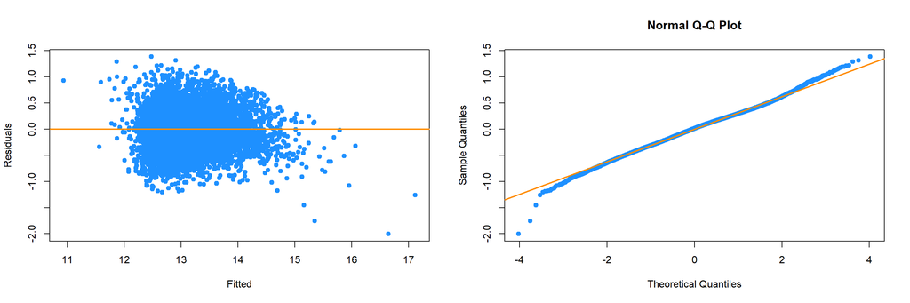

```r
par(mfrow=c(1,2))
plot_fitted_resid(house_model_bak_aic_add_all)
plot_qq(house_model_bak_aic_add_all)
```

- BP test for constant variance - p-Value under BP test is low which means assumption of constant variance is violated.

```r
library(lmtest)
bptest(house_model_bak_aic_add_all)
```

```
##
##  studentized Breusch-Pagan test
##
## data:  house_model_bak_aic_add_all
## BP = 439.52, df = 11, p-value < 2.2e-16
```

[Note: Since shapiro.test does not allow testing for more than 5000 samples, we have taken first 5000 rows.]

```r
shapiro.test(resid(house_model_bak_aic_add_all)[1:5000])
```

```
##
##  Shapiro-Wilk normality test
##
## data:  resid(house_model_bak_aic_add_all)[1:5000]
## W = 0.99769, p-value = 7.66e-07
```

- Both plots and p-values of tests suggest that this model `violates both assumption of normality and constant variance.` Therefore, we can use it for prediction but should not use for inference (i.e. test significance of coefficients.)

#### Try Box-cox transformation to transform response.

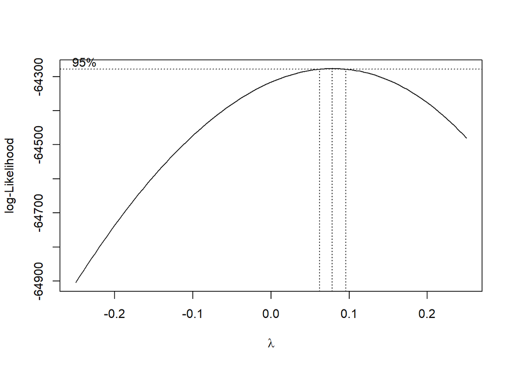

```r
# Note that response is not log transformed here.
model_start = lm(price ~ bedrooms + bathrooms + sqft_living + I(1/sqft_lot) + sqft_basement + yr_built + newFloors + newView + newCondition + grade,
                 data = train_house_data)

library(MASS)
library(faraway)

boxcox(model_start, plotit = TRUE, lambda = seq(-0.25, 0.25, by = 0.05))
```

- value of $\lambda = 0.08$

#### Transform response based on lambda and see the response.

```r
lam = 0.08
model_start = lm((price^ lam - 1)/lam  ~ bedrooms + bathrooms + sqft_living + I(1/sqft_lot) + sqft_basement + yr_built + newFloors + newView + newCondition + grade, data = train_house_data)

n = nrow(train_house_data)
house_model_bak_aic_add_all = step(model_start, direction = "backward", k = 2, trace = 0)
summary(house_model_bak_aic_add_all)$adj.r.squared
```

```
## [1] 0.6565053
```

```r
length(coef(house_model_bak_aic_add_all))
```

```
## [1] 11
```

```r
calc_loocv_rmse(house_model_bak_aic_add_all)
```

```
## [1] 0.8899368
```

```r
summary(house_model_bak_aic_add_all)
```

```
##
## Call:
## lm(formula = (price^lam - 1)/lam ~ bedrooms + bathrooms + sqft_living +
##     I(1/sqft_lot) + yr_built + newFloors + newView + newCondition +
##     grade, data = train_house_data)
##
## Residuals:
##     Min      1Q  Median      3Q     Max
## -5.7100 -0.6009  0.0257  0.5805  3.9936
##
## Coefficients:
##                 Estimate Std. Error t value Pr(>|t|)
## (Intercept)    4.848e+01  5.797e-01  83.623  < 2e-16 ***
## bedrooms      -5.894e-02  9.232e-03  -6.385 1.76e-10 ***
## bathrooms      2.169e-01  1.578e-02  13.744  < 2e-16 ***
## sqft_living    5.967e-04  1.572e-05  37.958  < 2e-16 ***
## I(1/sqft_lot)  8.294e+02  4.789e+01  17.318  < 2e-16 ***
## yr_built      -1.649e-02  3.040e-04 -54.245  < 2e-16 ***
## newFloors      7.991e-02  1.769e-02   4.518 6.29e-06 ***
## newView1       4.144e-01  2.607e-02  15.899  < 2e-16 ***
## newCondition1  3.912e-01  7.055e-02   5.546 2.97e-08 ***
## newCondition2  5.072e-01  7.054e-02   7.190 6.73e-13 ***
## grade          6.309e-01  9.851e-03  64.044  < 2e-16 ***
## ---
## Signif. codes:  0 '***' 0.001 '**' 0.01 '*' 0.05 '.' 0.1 ' ' 1
##
## Residual standard error: 0.8895 on 17279 degrees of freedom
## Multiple R-squared:  0.6567, Adjusted R-squared:  0.6565
## F-statistic:  3305 on 10 and 17279 DF,  p-value: < 2.2e-16
```

#### Find outliers.

```r
noOutliersTrainData = train_house_data[-which(cooks.distance(house_model_bak_aic_add_all) > 4/ nrow(train_house_data)), 1]
length(noOutliersTrainData)
```

```
## [1] 16418
```

```r
# model_start = lm(log(price) ~ bedrooms + bathrooms + sqft_living + I(1/sqft_lot) + sqft_basement + yr_built + newFloors + newView + newCondition + grade,
#                  data = train_house_data,
#                 subset = cooks.distance(house_model_bak_aic_add_all) <= 4/ nrow(train_house_data))

model_start = lm((price^ lam - 1)/lam  ~ bedrooms + bathrooms + sqft_living + I(1/sqft_lot) + sqft_basement + yr_built + newFloors + newView + newCondition + grade, data = train_house_data, subset = cooks.distance(house_model_bak_aic_add_all) <= 4/ nrow(train_house_data))

house_model_bak_aic_add_all = step(model_start, direction = "backward", k = 2, trace = 0)
summary(house_model_bak_aic_add_all)$adj.r.squared
```

```
## [1] 0.6840224
```

```r
length(coef(house_model_bak_aic_add_all))
```

```
## [1] 12
```

```r
calc_loocv_rmse(house_model_bak_aic_add_all)
```

```
## [1] 0.7858156
```

- Predict

```r
newTest = convertToNewHouseStr(test_house_data)
predictions = predict(house_model_bak_aic_add_all, newdata = newTest)

# Need to take exponent of prediction because it was log in the model.
# sqrt(mean((exp(predictions) - newTest$price) ^2))
sqrt(mean((removeTransformation(predictions, lam) - newTest$price) ^2))
```

```
## [1] 204991.2
```